# Session 7: Scraping Static Web Pages

Introduction to Web Scraping and Data Management for Social Scientists

Johannes B. Gruber

2026-07-28

# Introduction

## This Course

| Day | Session |
| --- | --- |
| 1 | Introduction |
| 2 | Data Structures and Wrangling |
| 3 | Working with Files |
| 4 | Linking and joining data & SQL |
| 5 | Database Software and Scaling your Analyses |
| 6 | Introduction to the Web |
| 7 | Static Web Pages |
| 8 | Application Programming Interface (APIs) |
| 9 | Interactive Web Pages |
| 10 | Building a Reproducible Research Project |

## The Plan for Today

In this session, we trap some **docile data** that wants to be found. We will:

- Go over some parsing examples:
  - Wikipedia: World World Happiness Report
- Discuss some examples of good approaches to data wrangling
- Go into a bit more detail on requesting raw data

Original Image Source: prowebscraper.com

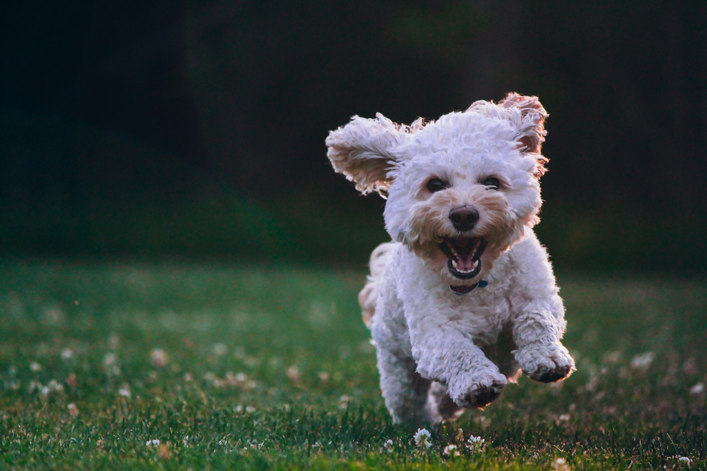

[Joe Caione](https://unsplash.com/@joeyc) via unsplash.com

# Correction: xpaths

- When I told you it’s not worth learning xpath, I was thinking about static xpaths like this:

```xml
/html/body/div[3]/div/div[3]/main/div[3]/div[3]/div[2]/section[4]/section/table/tbody/tr[1]/td[3]/div[1]/a
```

- However, I forgot that dynmic xpath also exists, which looks like this:

```xml
"descendant-or-self::table/descendant::a"
```

- Which is actually what `rvest` always uses under the hood by translating CSS to xpath with the `selectr` package:

```r
selectr::css_to_xpath("table a")
```

```
[1] "descendant-or-self::table/descendant::a"
```

- This dynamic xpath can be very useful and contains more functionality than CSS selectors, but it’s harder to learn and only useful in special cases

# Example: World Happiness Report

## Use your Browser to Scout

[figure not shown]

[figure not shown]

[figure not shown]

## Use your Browser’s `Inspect` tool

[figure not shown]

*Note: Might not be available on all browsers; use Chromium-based or Firefox.*

## Use `rvest` to scrape

```r
library(rvest)
library(tidyverse)

# 1. Request & collect raw html
html <- read_html(
  "https://en.wikipedia.org/w/index.php?title=World_Happiness_Report&oldid=1165407285"
)

# 2. Parse
happy_table <- html |>
  html_elements(".wikitable") |> # select the right element
  html_table() |> # special function for tables
  pluck(3) # select the third table

# 3. No wrangling necessary
happy_table
```

```
# A tibble: 153 × 9
   `Overall rank` `Country or region` Score `GDP per capita` `Social support`
            <int> <chr>               <dbl>            <dbl>            <dbl>
 1              1 Finland              7.81             1.28             1.5
 2              2 Denmark              7.65             1.33             1.50
 3              3 Switzerland          7.56             1.39             1.47
 4              4 Iceland              7.50             1.33             1.55
 5              5 Norway               7.49             1.42             1.50
 6              6 Netherlands          7.45             1.34             1.46
 7              7 Sweden               7.35             1.32             1.43
 8              8 New Zealand          7.3              1.24             1.49
 9              9 Austria              7.29             1.32             1.44
10             10 Luxembourg           7.24             1.54             1.39
# ℹ 143 more rows
# ℹ 4 more variables: `Healthy life expectancy` <dbl>,
#   `Freedom to make life choices` <dbl>, Generosity <dbl>,
#   `Perceptions of corruption` <dbl>
```

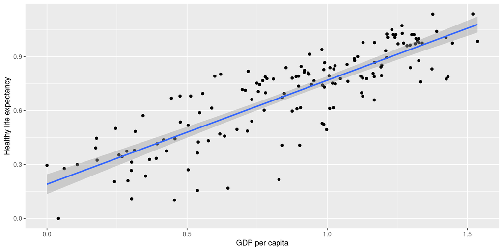

```r
## Plot relationship wealth and life expectancy
ggplot(happy_table, aes(x = `GDP per capita`, y = `Healthy life expectancy`)) +
  geom_point() +
  geom_smooth(method = 'lm')
```

## Exercises 1

1. Get the table with 2025 opinion polling for the next United Kingdom general election from https://en.wikipedia.org/w/index.php?title=Opinion_polling_for_the_next_United_Kingdom_general_election&oldid=1366502041
2. Wrangle and plot the data opinion polls

# Example: UK prime ministers on Wikipedia

## Use your Browser to Scout

[figure not shown]

## Use `rvest` to scrape

```r
# 1. Request & collect raw html
html <- read_html(
  "https://en.wikipedia.org/w/index.php?title=List_of_prime_ministers_of_the_United_Kingdom&oldid=1366130861"
) # I pinned this to the version 13:01, 26 July 2026 so that it still works, even if the site is updated

# 2. Parse
pm_table <- html |>
  html_elements(".wikitable") |>
  keep(function(x) str_detect(html_text(x), "List of prime ministers")) |>
  map(function(x) as_tibble(html_table(x), .name_repair = "unique")) |>
  bind_rows() |>
  as_tibble(.name_repair = "unique") |>
  filter(!duplicated(`Prime ministerOffice(lifespan)`))

# 3. No wrangling necessary
pm_table
```

```
# A tibble: 78 × 11
   Portrait...1 Portrait...2 Prime ministerOffice(lifespa…¹ `Term of office...4`
   <chr>        <chr>        <chr>                          <chr>
 1 "Portrait"   "Portrait"   Prime ministerOffice(lifespan) Start
 2 ""           ""           Robert Walpole[27]MP for King… 3 April 1721
 3 ""           ""           Spencer Compton[28]1st Earl o… 16 February 1742
 4 ""           ""           Henry Pelham[29]MP for Sussex… 27 August 1743[e]
 5 ""           ""           Thomas Pelham-Holles[30]1st D… 16 March 1754
 6 ""           ""           William Cavendish[31]4th Duke… 16 November 1756
 7 ""           ""           Thomas Pelham-Holles[32]1st D… 29 June 1757
 8 ""           ""           John Stuart[33]3rd Earl of Bu… 26 May 1762
 9 ""           ""           George Grenville[34]MP for Bu… 16 April 1763
10 ""           ""           Charles Watson-Wentworth[35]2… 13 July 1765
# ℹ 68 more rows
# ℹ abbreviated name: ¹`Prime ministerOffice(lifespan)`
# ℹ 7 more variables: `Term of office...5` <chr>, `Term of office...6` <chr>,
#   `Mandate[a]` <chr>, `Ministerial offices held as prime minister` <chr>,
#   `Party[b]` <chr>, Government <chr>, MonarchReign <chr>
```

```
<td rowspan="4">
  <span class="anchor" id="18th_century"></span>
   <b>
     <a href="/wiki/Robert_Walpole" title="Robert Walpole">Robert Walpole</a>
   </b>
   <sup id="cite_ref-FOOTNOTEEccleshallWalker20021,_5EnglefieldSeatonWhite19951–5PrydeGreenwayPorterRoy199645–46_28-0" class="reference">
     <a href="#cite_note-FOOTNOTEEccleshallWalker20021,_5EnglefieldSeatonWhite19951–5PrydeGreenwayPorterRoy199645–46-28">[27]</a>
   </sup>
   <br>
   <span style="font-size:85%;">MP for <a href="/wiki/King%27s_Lynn_(UK_Parliament_constituency)" title="King's Lynn (UK Parliament constituency)">King's Lynn</a>
   <br>(1676–1745)
  </span>
</td>
```

```r
links <- html |>
  html_elements(".wikitable") |>
  keep(function(x) str_detect(html_text(x), "List of prime ministers")) |>
  html_elements("td [style=\"font-size:100%;\"] a[title]") |>
  html_attr("href")
title <- html |>
  html_elements(".wikitable") |>
  keep(function(x) str_detect(html_text(x), "List of prime ministers")) |>
  html_elements("td [style=\"font-size:100%;\"] a[title]") |>
  html_text()
tibble(name = title, link = links)
```

```
# A tibble: 81 × 2
   name                     link
   <chr>                    <chr>
 1 Robert Walpole           https://en.wikipedia.org/wiki/Robert_Walpole
 2 Spencer Compton          https://en.wikipedia.org/wiki/Spencer_Compton,_1st_…
 3 Henry Pelham             https://en.wikipedia.org/wiki/Henry_Pelham
 4 Thomas Pelham-Holles     https://en.wikipedia.org/wiki/Thomas_Pelham-Holles
 5 William Cavendish        https://en.wikipedia.org/wiki/William_Cavendish,_4t…
 6 Thomas Pelham-Holles     https://en.wikipedia.org/wiki/Thomas_Pelham-Holles
 7 John Stuart              https://en.wikipedia.org/wiki/John_Stuart,_3rd_Earl…
 8 George Grenville         https://en.wikipedia.org/wiki/George_Grenville
 9 Charles Watson-Wentworth https://en.wikipedia.org/wiki/Charles_Watson-Wentwo…
10 William Pitt the Elder   https://en.wikipedia.org/wiki/William_Pitt_the_Elder
# ℹ 71 more rows
```

## Exercises 2

1. For extracting text, `rvest` has two functions: `html_text` and `html_text2`. Explain the difference. You can test your explanation with the example html below.

```r
html <- "<p>This is some text
         some more text</p><p>A new paragraph!</p>
         <p>Quick Question, is web scraping:

         a) fun
         b) tedious
         c) I'm not sure yet!</p>" |>
  read_html()
```

2. Wikipedia recently started using absolute links. Before that, they used relative links, such as many other websites still do. Relative links look like this:

```r
links <- c(
  "/wiki/Robert_Walpole",
  "/wiki/Spencer_Compton,_1st_Earl_of_Wilmington",
  "/wiki/Henry_Pelham",
  "/wiki/Thomas_Pelham-Holles",
  "/wiki/William_Cavendish,_4th_Duke_of_Devonshire",
  "/wiki/Thomas_Pelham-Holles",
  "/wiki/John_Stuart,_3rd_Earl_of_Bute",
  "/wiki/George_Grenville",
  "/wiki/Charles_Watson-Wentworth",
  "/wiki/William_Pitt_the_Elder",
  "/wiki/Augustus_FitzRoy,_3rd_Duke_of_Grafton",
  "/wiki/Frederick_North,_Lord_North",
  "/wiki/Charles_Watson-Wentworth",
  "/wiki/William_Petty,_2nd_Earl_of_Shelburne",
  "/wiki/William_Cavendish-Bentinck,_3rd_Duke_of_Portland",
  "/wiki/William_Pitt_the_Younger",
  "/wiki/Henry_Addington",
  "/wiki/William_Pitt_the_Younger",
  "/wiki/William_Grenville",
  "/wiki/William_Cavendish-Bentinck,_3rd_Duke_of_Portland",
  "/wiki/Spencer_Perceval",
  "/wiki/Robert_Jenkinson,_2nd_Earl_of_Liverpool",
  "/wiki/George_Canning",
  "/wiki/Frederick_John_Robinson",
  "/wiki/Arthur_Wellesley,_1st_Duke_of_Wellington",
  "/wiki/Charles_Grey,_2nd_Earl_Grey",
  "/wiki/William_Lamb,_2nd_Viscount_Melbourne",
  "/wiki/Arthur_Wellesley,_1st_Duke_of_Wellington",
  "/wiki/Robert_Peel",
  "/wiki/William_Lamb,_2nd_Viscount_Melbourne",
  "/wiki/Robert_Peel",
  "/wiki/Lord_John_Russell",
  "/wiki/Edward_Smith-Stanley,_14th_Earl_of_Derby",
  "/wiki/George_Hamilton-Gordon,_4th_Earl_of_Aberdeen",
  "/wiki/Henry_John_Temple",
  "/wiki/Edward_Smith-Stanley,_14th_Earl_of_Derby",
  "/wiki/Henry_John_Temple",
  "/wiki/John_Russell,_1st_Earl_Russell",
  "/wiki/Edward_Smith-Stanley,_14th_Earl_of_Derby",
  "/wiki/Benjamin_Disraeli",
  "/wiki/William_Ewart_Gladstone",
  "/wiki/Benjamin_Disraeli",
  "/wiki/William_Ewart_Gladstone",
  "/wiki/Robert_Gascoyne-Cecil,_3rd_Marquess_of_Salisbury",
  "/wiki/William_Ewart_Gladstone",
  "/wiki/Robert_Gascoyne-Cecil,_3rd_Marquess_of_Salisbury",
  "/wiki/William_Ewart_Gladstone",
  "/wiki/Archibald_Primrose,_5th_Earl_of_Rosebery",
  "/wiki/Robert_Gascoyne-Cecil,_3rd_Marquess_of_Salisbury",
  "/wiki/Arthur_Balfour",
  "/wiki/Henry_Campbell-Bannerman",
  "/wiki/H._H._Asquith",
  "/wiki/David_Lloyd_George",
  "/wiki/Bonar_Law",
  "/wiki/Stanley_Baldwin",
  "/wiki/Ramsay_MacDonald",
  "/wiki/Stanley_Baldwin",
  "/wiki/Ramsay_MacDonald",
  "/wiki/Stanley_Baldwin",
  "/wiki/Neville_Chamberlain",
  "/wiki/Winston_Churchill",
  "/wiki/Clement_Attlee",
  "/wiki/Winston_Churchill",
  "/wiki/Anthony_Eden",
  "/wiki/Harold_Macmillan",
  "/wiki/Alec_Douglas-Home",
  "/wiki/Harold_Wilson",
  "/wiki/Edward_Heath",
  "/wiki/Harold_Wilson",
  "/wiki/James_Callaghan",
  "/wiki/Margaret_Thatcher",
  "/wiki/John_Major",
  "/wiki/Tony_Blair",
  "/wiki/Gordon_Brown",
  "/wiki/David_Cameron",
  "/wiki/Theresa_May",
  "/wiki/Boris_Johnson",
  "/wiki/Liz_Truss",
  "/wiki/Rishi_Sunak",
  "/wiki/Keir_Starmer",
  "/wiki/Andy_Burnham"
)
```

How could you convert the `links` object above so that it contains actual URLs?

3. How could you add the links we extracted above to the `pm_table` to keep everything together?

# Example: thomann customer reviews

## Goal

1. Collect all reviews from a given Thomann page
2. Identify and extract relevant variables for each review

[figure not shown]

## Scout

After clicking on reviews, then “Read all reviews”, these are the links to the first three pages:

1. https://www.thomann.co.uk/beyerdynamic_dt770_pro80_ohm_reviews.htm
2. https://www.thomann.co.uk/beyerdynamic_dt770_pro80_ohm_reviews.htm?order=&page=2&rating=0
3. https://www.thomann.co.uk/beyerdynamic_dt770_pro80_ohm_reviews.htm?order=&page=3&rating=0

## URLs explained

- Uniform Resource Locator (URL) is a key mechanisms used to identify resources on a website for retrieval

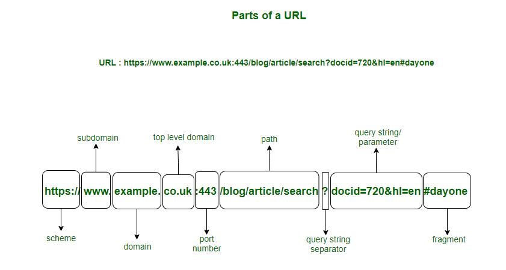

## Getting all URLs to product reviews

```r
pages <- 1:45
links <- paste0(
  "https://www.thomann.co.uk/beyerdynamic_dt770_pro80_ohm_reviews.htm",
  "?page=",
  pages,
  "&order=&rating=0"
)
links
```

```
 [1] "https://www.thomann.co.uk/beyerdynamic_dt770_pro80_ohm_reviews.htm?page=1&order=&rating=0"
 [2] "https://www.thomann.co.uk/beyerdynamic_dt770_pro80_ohm_reviews.htm?page=2&order=&rating=0"
 [3] "https://www.thomann.co.uk/beyerdynamic_dt770_pro80_ohm_reviews.htm?page=3&order=&rating=0"
 [4] "https://www.thomann.co.uk/beyerdynamic_dt770_pro80_ohm_reviews.htm?page=4&order=&rating=0"
 [5] "https://www.thomann.co.uk/beyerdynamic_dt770_pro80_ohm_reviews.htm?page=5&order=&rating=0"
 [6] "https://www.thomann.co.uk/beyerdynamic_dt770_pro80_ohm_reviews.htm?page=6&order=&rating=0"
 [7] "https://www.thomann.co.uk/beyerdynamic_dt770_pro80_ohm_reviews.htm?page=7&order=&rating=0"
 [8] "https://www.thomann.co.uk/beyerdynamic_dt770_pro80_ohm_reviews.htm?page=8&order=&rating=0"
 [9] "https://www.thomann.co.uk/beyerdynamic_dt770_pro80_ohm_reviews.htm?page=9&order=&rating=0"
[10] "https://www.thomann.co.uk/beyerdynamic_dt770_pro80_ohm_reviews.htm?page=10&order=&rating=0"
[11] "https://www.thomann.co.uk/beyerdynamic_dt770_pro80_ohm_reviews.htm?page=11&order=&rating=0"
[12] "https://www.thomann.co.uk/beyerdynamic_dt770_pro80_ohm_reviews.htm?page=12&order=&rating=0"
[13] "https://www.thomann.co.uk/beyerdynamic_dt770_pro80_ohm_reviews.htm?page=13&order=&rating=0"
[14] "https://www.thomann.co.uk/beyerdynamic_dt770_pro80_ohm_reviews.htm?page=14&order=&rating=0"
[15] "https://www.thomann.co.uk/beyerdynamic_dt770_pro80_ohm_reviews.htm?page=15&order=&rating=0"
```

[output cut: 30 more lines]

## Collecting the reviews from 1 page

```r
# make sure to read the HTML in only once
html <- read_html(links[1])

# we select review elements first
reviews <- html |>
  html_elements(".customer-review")

# then extract the information from these reviews
title <- reviews |>
  html_elements(".review-intro__headline.js-headline-original") |>
  html_text2()

date <- reviews |>
  html_elements(".review-intro__author") |>
  html_text2() |>
  str_extract("\\d{2}.\\d{2}.\\d{4}") |>
  lubridate::dmy()

text <- reviews |>
  html_elements(".review-text .fx-text-collapsible__fallback") |>
  html_text2()

# the rating system on this page is very interesting, instead of showing you
# a number of stars, it overlays greyed out stars with a colour and sets a
# width. 60% width of filled stars means 3/5 stars
star_ratings <- function(pct) {
  as.integer(pct) / 100 * 5
}
rating <- reviews |>
  html_elements(".fx-rating-stars__filler") |>
  html_attr("style") |>
  str_extract("(?<=width: )\\d+?(?=%)") |>
  star_ratings()


tibble(date, rating, title, text)
```

```
# A tibble: 10 × 4
   date       rating title                                                 text
   <date>      <dbl> <chr>                                                 <chr>
 1 2021-03-17      5 "Delivery to UK and Brexit"                           "I o…
 2 2020-05-29      5 "Absolutely gorgeous ..."                             "I a…
 3 2020-09-11      5 "YES YES YES"                                         "Fin…
 4 2017-12-19      5 "Great sound and quality"                             "I u…
 5 2022-12-11      1 "Unfortunately, Beyer is bought because others are b… "Onc…
 6 2024-12-20      5 "Great headphones for the price"                      "Bou…
 7 2019-08-23      5 "Used them for a few weeks now, love them."           "Fir…
 8 2026-02-24      4 "The Treble Trap"                                     "The…
 9 2022-04-08      5 "King in headphones world"                            "Tho…
10 2021-07-27      5 ""                                                    "For…
```

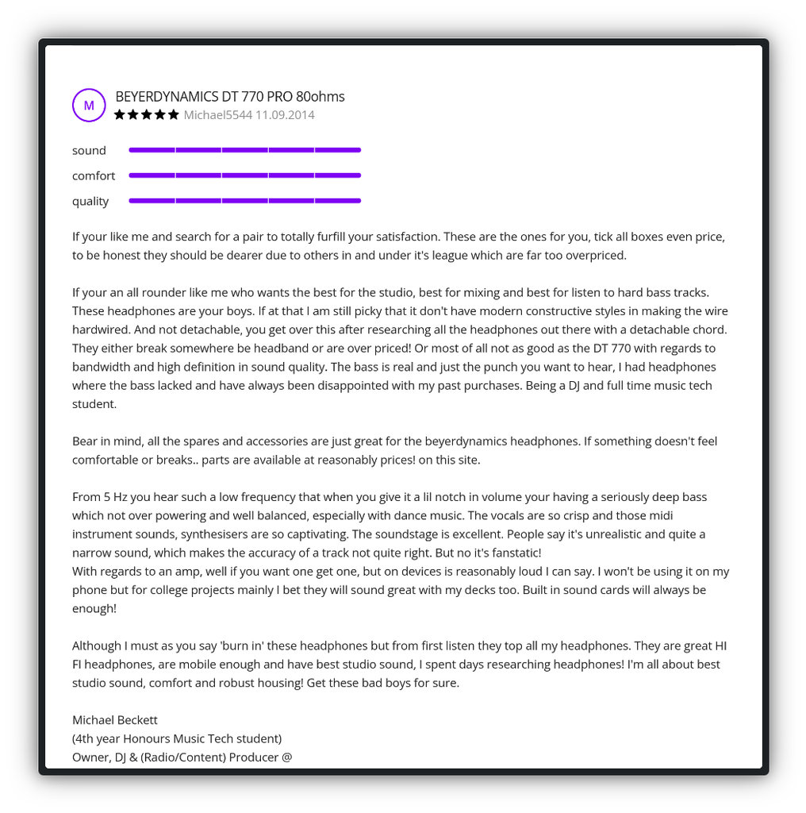

## (Un)helpful reviews rating

```r
helpful <- reviews |>
  html_elements(".action [data-vote-rating-type=\"up\"] .action__value") |>
  html_text2() |>
  as.integer()
helpful
```

```
 [1] 35 28 20 25 17  0  3  1  1  0
```

```r
unhelpful <- reviews |>
  html_elements(".action [data-vote-rating-type=\"down\"] .action__value") |>
  html_text2() |>
  as.integer()
unhelpful
```

```
 [1] 7 1 5 0 1 0 1 0 0 0
```

```r
tibble(date, rating, helpful, unhelpful, title, text)
```

```
# A tibble: 10 × 6
   date       rating helpful unhelpful title                               text
   <date>      <dbl>   <int>     <int> <chr>                               <chr>
 1 2021-03-17      5      35         7 "Delivery to UK and Brexit"         "I o…
 2 2020-05-29      5      28         1 "Absolutely gorgeous ..."           "I a…
 3 2020-09-11      5      20         5 "YES YES YES"                       "Fin…
 4 2017-12-19      5      25         0 "Great sound and quality"           "I u…
 5 2022-12-11      1      17         1 "Unfortunately, Beyer is bought be… "Onc…
 6 2024-12-20      5       0         0 "Great headphones for the price"    "Bou…
 7 2019-08-23      5       3         1 "Used them for a few weeks now, lo… "Fir…
 8 2026-02-24      4       1         0 "The Treble Trap"                   "The…
 9 2022-04-08      5       1         0 "King in headphones world"          "Tho…
10 2021-07-27      5       0         0 ""                                  "For…
```

[figure not shown]

## Make it safer: Iterate over cases, rather than variable values

- you can go over a nodeset and extract every matching value, then assemble results
- as soon as one element is missing in one of the nodesets, it errors
- safer: treat nodeset of reviews as list and iterate over each element

```r
check_len <- function(x, len = 1, .default = NA) {
  if (length(x) != len) {
    return(rep(.default, len))
  } else {
    return(x)
  }
}

parse_review <- function(r) {
  date <- r |>
    html_elements(".review-intro__author") |>
    html_text2() |>
    str_extract("\\d{2}.\\d{2}.\\d{4}") |>
    lubridate::dmy() |>
    check_len()

  rating <- r |>
    html_elements(".fx-rating-stars__filler") |>
    html_attr("style") |>
    str_extract("(?<=width: )\\d+?(?=%)") |>
    star_ratings() |>
    check_len()

  helpful <- r |>
    html_elements(".action [data-vote-rating-type=\"up\"] .action__value") |>
    html_text2() |>
    as.integer() |>
    check_len()

  unhelpful <- r |>
    html_elements(".action [data-vote-rating-type=\"down\"] .action__value") |>
    html_text2() |>
    as.integer() |>
    check_len()

  title <- r |>
    html_elements(".review-intro__headline.js-headline-original") |>
    html_text2() |>
    check_len()

  text <- r |>
    html_elements(".review-text .fx-text-collapsible__fallback") |>
    html_text2() |>
    check_len()

  tibble(date, rating, helpful, unhelpful, title, text)
}

map(reviews, parse_review) |>
  bind_rows()
```

```
# A tibble: 10 × 6
   date       rating helpful unhelpful title                               text
   <date>      <dbl>   <int>     <int> <chr>                               <chr>
 1 2021-03-17      5      35         7 "Delivery to UK and Brexit"         "I o…
 2 2020-05-29      5      28         1 "Absolutely gorgeous ..."           "I a…
 3 2020-09-11      5      20         5 "YES YES YES"                       "Fin…
 4 2017-12-19      5      25         0 "Great sound and quality"           "I u…
 5 2022-12-11      1      17         1 "Unfortunately, Beyer is bought be… "Onc…
 6 2024-12-20      5       0         0 "Great headphones for the price"    "Bou…
 7 2019-08-23      5       3         1 "Used them for a few weeks now, lo… "Fir…
 8 2026-02-24      4       1         0 "The Treble Trap"                   "The…
 9 2022-04-08      5       1         0 "King in headphones world"          "Tho…
10 2021-07-27      5       0         0 ""                                  "For…
```

## Iterate over pages to collect all reviews

```r
get_reviews_from_page <- function(link) {
  html <- try(read_html(link))

  while (is(html, "try-error")) {
    Sys.sleep(3)
    html <- try(read_html(link))
  }

  reviews <- html |>
    html_elements(".customer-review")

  map(reviews, parse_review) |>
    bind_rows()
}

all_reviews <- map(
  links[1:3],
  get_reviews_from_page,
  .progress = interactive()
) |>
  bind_rows()
glimpse(all_reviews)
```

```
Rows: 30
Columns: 6
$ date      <date> 2021-03-17, 2020-05-29, 2020-09-11, 2017-12-19, 2022-12-11,…
$ rating    <dbl> 5, 5, 5, 5, 1, 5, 5, 4, 5, 5, 5, 5, 5, 5, 5, 5, 3, 4, 5, 5, …
$ helpful   <int> 35, 28, 20, 25, 17, 0, 3, 1, 1, 0, 1, 0, 4, 2, 0, 1, 1, 0, 0…
$ unhelpful <int> 7, 1, 5, 0, 1, 0, 1, 0, 0, 0, 0, 0, 0, 0, 0, 0, 0, 0, 0, 0, …
$ title     <chr> "Delivery to UK and Brexit", "Absolutely gorgeous ...", "YES…
$ text      <chr> "I ordered these, together with a headband and a pair of Sen…
```

## Exercises 3

We might be interested in product specific rating scales (sound, comfort, and quality)

1. Extract that information from the first review page (hint: it works similar to the star rating and you can reuse that function)
2. Each review has 3 feature ratings, extract the labels to those ratings and combine them with the ratings themselves into a data.frame
3. Add the variables sound, comfort, and quality to the `parse_review` function (hint: you will need `pivot_wider`)
4. Create `all_reviews` again, but with the feature ratings this time

# Example: Getting content from embedded json

## Goal

1. Collect news articles from news.sky.com
2. Get the text of an article, the headline, date, and author

[figure not shown]

## Scout

Let’s look for the date information in the page source

[figure not shown]

## A Wild JSON string Appears!

- JavaScript Object Notation (json) is a way of storing complicated nested data in plain text (see session 3)
- data is put into a character string that indicates object types and relation of objects
- R knows how to read json strings/files and can easily process them

```r
library(jsonlite)
json_string <- list(x = 1:10, y = list(z = 1:10, a = LETTERS[1:10])) |>
  toJSON()
json_string
```

```
{"x":[1,2,3,4,5,6,7,8,9,10],"y":{"z":[1,2,3,4,5,6,7,8,9,10],"a":["A","B","C","D","E","F","G","H","I","J"]}}
```

```r
fromJSON(json_string)
```

```
$x
 [1]  1  2  3  4  5  6  7  8  9 10

$y
$y$z
 [1]  1  2  3  4  5  6  7  8  9 10

$y$a
 [1] "A" "B" "C" "D" "E" "F" "G" "H" "I" "J"
```

- essentially we seem to get pre-packaged data here

## Obtain the JSON string

```r
# 1. Request & collect raw html
html <- read_html(
  "https://web.archive.org/web/20250819084103/https://news.sky.com/story/crowdstrike-company-that-caused-global-techno-meltdown-offers-partners-10-vouchers-to-say-sorry-and-they-dont-work-13184488"
)

# 2. Parse
json_string <- html |>
  rvest::html_element("[type=\"application/ld+json\"]") |>
  rvest::html_text()

# 3. wrangling (part 1)
data <- jsonlite::fromJSON(json_string)
```

Why I use the *Internet Archive*’s version:

```r
html <- read_html(
  "https://news.sky.com/story/crowdstrike-company-that-caused-global-techno-meltdown-offers-partners-10-vouchers-to-say-sorry-and-they-dont-work-13184488"
)
```

```
Error in `open.connection()`:
! cannot open the connection
```

## Wrangling part 2

From here it is really straightforward to extract (most of) the relevant information:

```r
# datetime
datetime <- pluck(data, "datePublished") |>
  lubridate::as_datetime()

# headline
headline <- pluck(data, "headline")

# author
author <- pluck(data, "author", "name")
```

The only thing missing from this data is the article itself…

## Getting the article

```r
text <- html |>
  rvest::html_elements(".sdc-article-body p") |>
  rvest::html_text2() |>
  paste(collapse = "\n")
```

```r
sky_article <- tibble(datetime, author, headline, text)
glimpse(sky_article)
```

```
Rows: 1
Columns: 4
$ datetime <dttm> 2024-07-24 20:33:00
$ author   <chr> "Claire Gilbody Dickerson, news reporter"
$ headline <chr> "CrowdStrike: Company that caused global techno meltdown off…
$ text     <chr> "The firm behind the global IT outage that cost companies bil…
```

## Exercises 4

1. Get the author, publication datetime, headline and text from this site: https://www.cnet.com/tech/services-and-software/facebook-hopes-to-normalize-idea-of-data-scraping-leaks-says-leaked-internal-memo/ (hint: it works in a very similar way, but you have to apply one extra data wrangling step)

# Example: zeit.de

## Special Requests: Behind Paywall

Let’s get this [cool data journalism article](https://www.zeit.de/mobilitaet/2024-04/deutschlandticket-klimaschutz-oeffentliche-verkehrsmittel-autos-verkehrswende).

```r
html <- read_html(
  "https://www.zeit.de/mobilitaet/2024-04/deutschlandticket-klimaschutz-oeffentliche-verkehrsmittel-autos-verkehrswende"
)
html |>
  html_elements(".article-body p") |>
  html_text2()
```

```
[1] "Ganz Deutschland fährt Bahn. So fühlte sich das im Sommer 2022 zumindest an, als das 9-Euro-Ticket für drei Monate für überfüllte Züge sorgte. Die Bundesregierung und viele Menschen zeigten sich begeistert: So leicht war es also, Bürgerinnen und Bürger für die umweltfreundlichen öffentlichen Ve…
[2] "Aber als die Bundesregierung den Nachfolger vorstellte, waren viele enttäuscht. 49 Euro monatlich kostet das Deutschlandticket und ist nur im Abo erhältlich. Euphorisch war nur noch die Bundesregierung. Doch jetzt, ein Jahr nach dem Start, kann man sagen: zu Recht. Zumindest, was die Fahrgastza…
```

🤔 Wait, that’s only the first two paragraphs!

**Tip**

Websites use cookies to remember users (including logged in ones)

## What are browser cookies

- Small pieces of data stored on the user’s device by the web browser while browsing websites
- **Purpose**:
  - **Session Management**: Maintain user sessions by storing login information and keeping users logged in as they navigate a website.
  - **Personalization**: Save user preferences, such as language settings or theme choices, to enhance user experience.
  - **Tracking and Analytics**: Track user behavior across websites for analytics and targeted advertising.
- We can use them in scraping:
  - to get content from websites that require consent before giving access
  - to authenticate as a user with content access privileges
  - to access personalized content
  - to simulate real user behavior, reducing the chances of getting blocked by websites with anti-scraping measures
- You can use browser extensions like [“Get cookies.txt”](https://chrome.google.com/webstore/detail/get-cookiestxt-locally/cclelndahbckbenkjhflpdbgdldlbecc) for Chromium-based browsers or [“cookies.txt”](https://addons.mozilla.org/en-US/firefox/addon/cookies-txt/) for Firefox to save your cookies to a file
- Implications:
  - You need to keep cookies secure as they can authenticate others as you!

## Special Requests: Behind Paywall Cookies!

```r
library(cookiemonster)
add_cookies("cookies.txt")
```

```r
library(httr2)
html <- request(
  "https://www.zeit.de/mobilitaet/2024-04/deutschlandticket-klimaschutz-oeffentliche-verkehrsmittel-autos-verkehrswende"
) |> # start a request
  req_options(cookie = get_cookies("zeit.de", as = "string")) |> # add cookies to be sent with it
  req_perform() |>
  resp_body_html() # extract html from response

text <- html |>
  html_elements(".article-body p") |>
  html_text2()
length(text)
```

[output not shown]

# Example: South African Parliament (a special case)

## Goal

1. Collect information about any financial interest of South Africa’s Members of Parliament

[figure not shown]

## Collect links to PDF

```r
library(httr2)
# I use the internet archive here as the real website is incredibly slow
html <- request(
  "https://web.archive.org/web/20240519142346/https://www.parliament.gov.za/register-members-Interests"
) |>
  req_timeout(100) |>
  req_perform() |>
  resp_body_html()

links <- html |>
  html_elements(".parly-h2+ul a") |>
  html_attr("href") |>
  # some links are malformed
  str_remove("^/web/20240519142346/")

years <- html |>
  html_elements(".parly-h2+ul a") |>
  html_text()

interest_pdfs <- tibble(
  link = links,
  year = years
) |>
  mutate(file_name = paste0("data/za/", year, ".pdf"))
interest_pdfs
```

```
# A tibble: 15 × 3
   link                                                          year  file_name
   <chr>                                                         <chr> <chr>
 1 https://www.parliament.gov.za/storage/app/media/Register%20o… 2023  data/za/…
 2 https://www.parliament.gov.za/storage/app/media/Register%20o… 2022  data/za/…
 3 https://www.parliament.gov.za/storage/app/media/Register%20o… 2021  data/za/…
 4 https://www.parliament.gov.za/storage/app/media/Register%20o… 2020  data/za/…
 5 https://www.parliament.gov.za/storage/app/media/Register%20o… 2019  data/za/…
 6 https://web.archive.org/web/20240519142346/https://www.parli… 2018  data/za/…
 7 https://web.archive.org/web/20240519142346/https://www.parli… 2017  data/za/…
 8 https://web.archive.org/web/20240519142346/https://www.parli… 2016  data/za/…
 9 https://web.archive.org/web/20240519142346/https://www.parli… 2015  data/za/…
10 https://web.archive.org/web/20240519142346/https://www.parli… 2014  data/za/…
11 https://web.archive.org/web/20240519142346/https://www.parli… 2013  data/za/…
12 https://web.archive.org/web/20240519142346/https://www.parli… 2012  data/za/…
13 https://web.archive.org/web/20240519142346/https://www.parli… 2011  data/za/…
14 https://web.archive.org/web/20240519142346/https://www.parli… 2010  data/za/…
15 https://web.archive.org/web/20240519142346/https://www.parli… 2009  data/za/…
```

## Download files for processing

```r
dir.create("data/za", showWarnings = FALSE)
if (!file.exists("data/za/2018.pdf")) {
  # multi_download is a neat little function that parallesises file download
  curl::multi_download(
    urls = interest_pdfs$link,
    destfiles = interest_pdfs$file_name
  )
}
```

## Scraping data from PDFs?

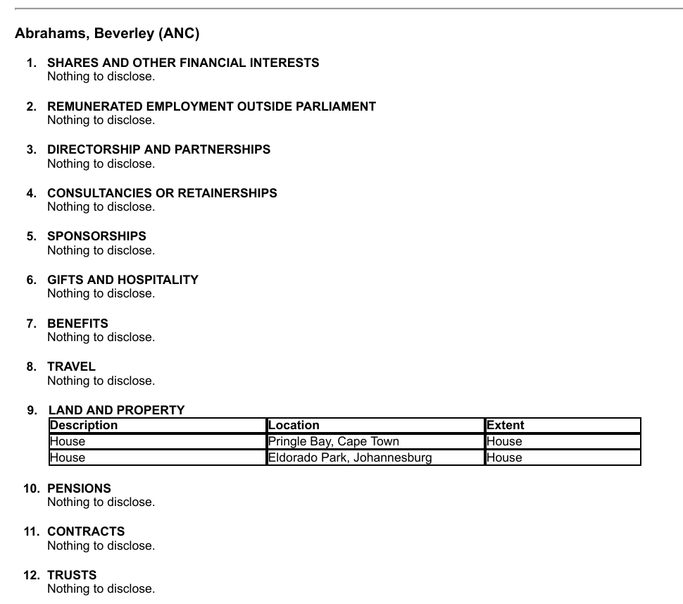

## Let’s investigate the PDF a little

```r
library(pdftools)
interests_pdf <- pdf_data("data/za/2018.pdf", font_info = TRUE)
glimpse(interests_pdf[[2]])
```

```
Rows: 172
Columns: 8
$ width     <int> 78, 31, 24, 6, 31, 16, 26, 40, 42, 25, 6, 29, 6, 57, 52, 33,…
$ height    <int> 9, 9, 9, 8, 8, 8, 8, 8, 8, 8, 8, 8, 8, 8, 8, 8, 8, 8, 8, 8, …
$ x         <int> 35, 115, 150, 41, 54, 87, 106, 134, 177, 54, 82, 90, 41, 54,…
$ y         <int> 65, 65, 65, 83, 83, 83, 83, 83, 83, 91, 91, 91, 109, 109, 10…
$ space     <lgl> TRUE, TRUE, FALSE, TRUE, TRUE, TRUE, TRUE, TRUE, FALSE, TRUE…
$ text      <chr> "Abraham-Ntantiso,", "Phoebe", "(ANC)", "1.", "SHARES", "AND…
$ font_name <chr> "Arial-BoldMT", "Arial-BoldMT", "Arial-BoldMT", "Arial-BoldM…
$ font_size <dbl> 8.775, 8.775, 8.775, 7.500, 7.500, 7.500, 7.500, 7.500, 7.50…
```

We see here that:

- each page is an element in a list
- each word is in one row of the table
- it contains the font_size and font_name
- the position of each word on tha page is given with x and y coordinates

## Let’s investigate the PDF a little

Let’s investigate a few words we saw above:

```r
# a politician name
interests_pdf[[2]] |>
  filter(str_detect(text, "Abrahams,"))
```

```
# A tibble: 1 × 8
  width height     x     y space text      font_name    font_size
  <int>  <int> <int> <int> <lgl> <chr>     <chr>            <dbl>
1    45      9    35   473 TRUE  Abrahams, Arial-BoldMT      8.78
```

```r
# an item header
interests_pdf[[2]] |>
  filter(str_detect(text, "1"))
```

```
# A tibble: 7 × 8
  width height     x     y space text  font_name    font_size
  <int>  <int> <int> <int> <lgl> <chr> <chr>            <dbl>
1     6      8    41    83 TRUE  1.    Arial-BoldMT      7.50
2    10      8    39   350 TRUE  10.   Arial-BoldMT      7.50
3    10      8    40   376 TRUE  11.   Arial-BoldMT      7.50
4    10      8    39   403 TRUE  12.   Arial-BoldMT      7.50
5    10      8    39   429 TRUE  13.   Arial-BoldMT      7.50
6     6      8    41   492 TRUE  1.    Arial-BoldMT      7.50
7    10      8    39   749 TRUE  10.   Arial-BoldMT      7.50
```

```r
# a disclose
interests_pdf[[2]] |>
  filter(str_detect(text, "disclose"))
```

```
# A tibble: 19 × 8
   width height     x     y space text      font_name font_size
   <int>  <int> <int> <int> <lgl> <chr>     <chr>         <dbl>
 1    29      8    90    91 FALSE disclose. ArialMT        7.50
 2    29      8    90   118 FALSE disclose. ArialMT        7.50
 3    29      8    90   144 FALSE disclose. ArialMT        7.50
 4    29      8    90   170 FALSE disclose. ArialMT        7.50
 5    29      8    90   196 FALSE disclose. ArialMT        7.50
 6    29      8    90   268 FALSE disclose. ArialMT        7.50
 7    29      8    90   295 FALSE disclose. ArialMT        7.50
 8    29      8    90   358 FALSE disclose. ArialMT        7.50
 9    29      8    90   385 FALSE disclose. ArialMT        7.50
10    29      8    90   411 FALSE disclose. ArialMT        7.50
11    29      8    90   437 FALSE disclose. ArialMT        7.50
12    29      8    90   500 FALSE disclose. ArialMT        7.50
13    29      8    90   526 FALSE disclose. ArialMT        7.50
14    29      8    90   553 FALSE disclose. ArialMT        7.50
15    29      8    90   579 FALSE disclose. ArialMT        7.50
16    29      8    90   605 FALSE disclose. ArialMT        7.50
17    29      8    90   631 FALSE disclose. ArialMT        7.50
18    29      8    90   658 FALSE disclose. ArialMT        7.50
19    29      8    90   684 FALSE disclose. ArialMT        7.50
```

```r
# a word inside table
interests_pdf[[2]] |>
  filter(str_detect(text, "Pringle"))
```

```
# A tibble: 1 × 8
  width height     x     y space text    font_name font_size
  <int>  <int> <int> <int> <lgl> <chr>   <chr>         <dbl>
1    23      8   188   721 TRUE  Pringle ArialMT        7.50
```

```r
# a table header
interests_pdf[[2]] |>
  filter(str_detect(text, "Description"))
```

```
# A tibble: 3 × 8
  width height     x     y space text        font_name    font_size
  <int>  <int> <int> <int> <lgl> <chr>       <chr>            <dbl>
1    41      8    56   223 FALSE Description Arial-BoldMT      7.50
2    41      8    56   322 FALSE Description Arial-BoldMT      7.50
3    41      8    56   711 FALSE Description Arial-BoldMT      7.50
```

Findings:

- It looks like we can say relatively easily where a new politician entry starts based on the font
- The item header has the same font name, but a different size
- We can tell quite easily on which items there is nothing to disclose
- The table colnames are similar to item headers, but start at a different x location

## Test extract info from one page

```r
p1 <- interests_pdf[[2]]
```

```r
# add whether politician name
p1 |>
  mutate(
    is_name = font_name == "Arial-BoldMT" &
      round(font_size, 3) == 8.775
  ) |>
  # add whether header
  mutate(
    is_header = font_name == "Arial-BoldMT" &
      round(font_size, 1) == 7.5
  )
```

```
# A tibble: 172 × 10
   width height     x     y space text     font_name font_size is_name is_header
   <int>  <int> <int> <int> <lgl> <chr>    <chr>         <dbl> <lgl>   <lgl>
 1    78      9    35    65 TRUE  Abraham… Arial-Bo…      8.78 TRUE    FALSE
 2    31      9   115    65 TRUE  Phoebe   Arial-Bo…      8.78 TRUE    FALSE
 3    24      9   150    65 FALSE (ANC)    Arial-Bo…      8.78 TRUE    FALSE
 4     6      8    41    83 TRUE  1.       Arial-Bo…      7.50 FALSE   TRUE
 5    31      8    54    83 TRUE  SHARES   Arial-Bo…      7.50 FALSE   TRUE
 6    16      8    87    83 TRUE  AND      Arial-Bo…      7.50 FALSE   TRUE
 7    26      8   106    83 TRUE  OTHER    Arial-Bo…      7.50 FALSE   TRUE
 8    40      8   134    83 TRUE  FINANCI… Arial-Bo…      7.50 FALSE   TRUE
 9    42      8   177    83 FALSE INTERES… Arial-Bo…      7.50 FALSE   TRUE
10    25      8    54    91 TRUE  Nothing  ArialMT        7.50 FALSE   FALSE
# ℹ 162 more rows
```

## Wrangle into shape

```r
p1_df <- p1 |>
  # one line in the PDF is all on the same y position
  group_by(y) |>
  # so we can summarise, ie. make one row out of one line
  summarise(
    # we retain only the first value from font_name, font_size and x
    # since they are all the same anyway
    font_name = head(font_name, 1),
    font_size = head(font_size, 1),
    x = head(x, 1),
    # we use paste with collapse to get several character values into
    # one string per line
    text = paste(text, collapse = " "),
    # dropping groups as we don't need them
    .groups = "drop"
  ) |>
  # we check whether a line is a name
  mutate(
    is_name = font_name == "Arial-BoldMT" &
      round(font_size, 3) == 8.775
  ) |>
  # and add a unique ID per person
  mutate(id = cumsum(is_name)) |>
  # now we do the same per disclosure item
  mutate(
    is_header = font_name == "Arial-BoldMT" &
      round(font_size, 1) == 7.5 &
      x < 50
  ) |>
  mutate(item_id = cumsum(is_header))
```

## Wrangle into shape

```r
p1_df_tidy <- p1_df |>
  # we group by person
  group_by(id) |>
  # and add a new variable with their name
  mutate(
    name = text[is_name],
  ) |>
  ungroup() |>
  # now we can remove the rows that contain the name in the text
  filter(!is_name) |>
  # we do the same per item
  group_by(item_id) |>
  mutate(
    item = text[is_header],
    content = paste(text[!is_header], collapse = "\n")
  ) |>
  # this produces a lot of duplicates, which we can get rid of with distinct
  distinct(name, item, content)
glimpse(p1_df_tidy)
```

```
Rows: 23
Columns: 4
Groups: item_id [23]
$ item_id <int> 1, 2, 3, 4, 5, 6, 7, 8, 9, 10, 11, 12, 13, 14, 15, 16, 17, 18,…
$ name    <chr> "Abraham-Ntantiso, Phoebe (ANC)", "Abraham-Ntantiso, Phoebe (A…
$ item    <chr> "1. SHARES AND OTHER FINANCIAL INTERESTS", "2. REMUNERATED EMP…
$ content <chr> "Nothing to disclose.", "Nothing to disclose.", "Nothing to di…
```

## Apply to whole PDF

First, we have to add a page number to each site:

```r
for (p in seq_along(interests_pdf)) {
  interests_pdf[[p]]$page <- p
}
```

## Apply to whole PDF

I’m sorry for this long code 😅

```r
interests_df <- bind_rows(interests_pdf) |>
  # one line in the PDF is all on the same y position
  group_by(page, y) |>
  # so we can summarise, ie. make one row out of one line
  summarise(
    # we retain only the first value from font_name, font_size and x
    # since they are all the same anyway
    font_name = head(font_name, 1),
    font_size = head(font_size, 1),
    x = head(x, 1),
    # we use paste with collapse to get several character values into
    # one string per line
    text = paste(text, collapse = " "),
    # dropping groups as we don't need them
    .groups = "drop"
  ) |>
  # we check whether a line is a name
  mutate(
    is_name = font_name == "Arial-BoldMT" &
      round(font_size, 3) == 8.775
  ) |>
  # and add a unique ID per person
  mutate(id = cumsum(is_name)) |>
  # everything before the first name can be removed
  filter(id != 0) |>
  # now we do the same per disclosure item
  mutate(
    is_header = font_name == "Arial-BoldMT" &
      round(font_size, 1) == 7.5 &
      x < 50
  ) |>
  mutate(item_id = cumsum(is_header)) |>
  # we group by person
  group_by(id) |>
  # and add a new variable with their name
  mutate(
    name = text[is_name],
  ) |>
  ungroup() |>
  # now we can remove the rows that contain the name in the text
  filter(!is_name) |>
  # we do the same per item
  group_by(item_id) |>
  mutate(
    item = text[is_header],
    content = paste(text[!is_header], collapse = "\n")
  ) |>
  # this produces a lot of duplicates, which we can get rid of with distinct
  ungroup() |>
  distinct(id, name, item, content)
```

## Exercises 5

First, review the material. What you should take from this section:

- websites might contain files containing the data you are interested in. Scraping the links and then downloading the files is a quick way to get access
- It is possible to extract data from PDFs, but not trivial
- The package `pdftools` has a `pdf_data` function which gives you much more flexibility to extract information systematically than `pdf_text`

That said, you can practice working with PDFs a litte

1. In the folder /data (relative to this document) there is a PDF with some text. Read it into R
2. The PDF has two columns, parse the left column of the first page into one object and the right into another
3. Now combine them and bring the text in the right order as a human would read it

Bonus:

4. Let’s assume you wanted to have this text in a table with one column indicating the section and one having the text of the section
5. Now let’s assume you wanted to parse this on the paragraph level instead (hint: remember `str_split`)

# Optional Homework

You have seen some tools and tricks to scrape websites now. But your best ally in web scraping is **experience**! Now your task is to **find a page on Wikipedia you find interesting and scrape content** from there. Even if you don’t fully succeed, document the steps you take and note down where the information can be found. If you want to try to get some data you actually need from a different website, your’re also welcome! But note that if you collect raw html in R and the data is not where it should be (e.g., the html elements containing panel names do not exist), you might have discovered a more advanced site, which we will cover later. Note that down and try another website.

Deadline: **Friday before class**